# Chi-squared test on Lotto Max

Zhongmang Cheng

2023-07-31

# A First Look at the Histograms

Prior to proceeding with the test, we would like to have a general idea of shape of the statistics. A comparison has been created between generated winning numbers and observed winning numbers.

Generated winning numbers was created using a discrete uniform random variable with a expectation of 1/50. Observed winning numbers was obtained from the official website of Lotto max: https://www.lottomaxnumbers.com/statistics

A first look at the data suggest that the observed data follows a normal distribution as expected, and that there is no abnormally.

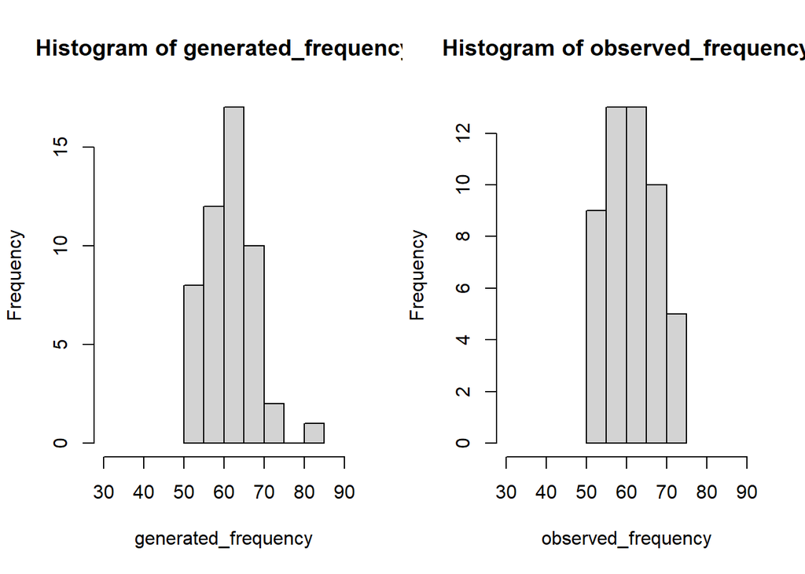

```r
set.seed(2345)
random_numbers <- sample(1:50, size = 3080, replace = TRUE)

generated_frequency <- table(random_numbers)
observed_frequency <- c(61, 62, 56, 62, 67, 53, 61, 54, 71, 57, 61, 56, 55, 70, 60, 54, 62, 65, 73, 51, 62, 66, 56, 60, 63, 70, 58, 63, 58, 64, 66, 71, 54, 55, 62, 69, 67, 69, 71, 68, 53, 57, 59, 65, 57, 73, 51, 66, 56, 60)

par(mfrow = c(1, 2))

hist(generated_frequency, xlim = range(30, 90))
hist(observed_frequency, xlim = range(30, 90))
```

# Chi-squared Test for Fair Game

We propose the following null hypothesis and alternative hypothesis:

H0: the lottery game is fair, the numbers are drawn randomly and without bias.  
HA: the lottery game is not fair, there is some form of bias or manipulation in the drawing process.

Chi-squared Test will be used to test our hypothesis.

```r
expected_frequency <- rep(1/50, 50)
observed_frequency <- c(61, 62, 56, 62, 67, 53, 61, 54, 71, 57, 61, 56, 55, 70, 60, 54, 62, 65, 73, 51, 62, 66, 56, 60, 63, 70, 58, 63, 58, 64, 66, 71, 54, 55, 62, 69, 67, 69, 71, 68, 53, 57, 59, 65, 57, 73, 51, 66, 56, 60)

chi_squared_test <- chisq.test(observed_frequency, p = expected_frequency)

print(chi_squared_test)
```

```
##
##  Chi-squared test for given probabilities
##
## data:  observed_frequency
## X-squared = 29.708, df = 49, p-value = 0.9867
```

**The result of the test indicates a p-value greater than the critical value (0.95).** **We failed to reject the null hypothesis (H0).**

This suggest that the numbers are very likely drawn randomly and without bias, and that Lotto Max is fair game.